# ggplot2: 2 First Steps

This notebook is based on exercises completed from [ggplot2: Elegant Graphics for Data Analysis](https://ggplot2-book.org/index.html).

```r
library(tidyverse)
#library(ggplot2)

# set global theme for graphs
theme_set(theme_bw())
```

## 2.2.1 Fuel Economy Data

1.List five functions that you could use to get more information about the mpg data set.

```r
summary(mpg)
```

```
 manufacturer          model               displ            year           cyl           trans
 Length:234         Length:234         Min.   :1.600   Min.   :1999   Min.   :4.000   Length:234
 Class :character   Class :character   1st Qu.:2.400   1st Qu.:1999   1st Qu.:4.000   Class :character
 Mode  :character   Mode  :character   Median :3.300   Median :2004   Median :6.000   Mode  :character
                                       Mean   :3.472   Mean   :2004   Mean   :5.889
                                       3rd Qu.:4.600   3rd Qu.:2008   3rd Qu.:8.000
                                       Max.   :7.000   Max.   :2008   Max.   :8.000
     drv                 cty             hwy             fl               class
 Length:234         Min.   : 9.00   Min.   :12.00   Length:234         Length:234
 Class :character   1st Qu.:14.00   1st Qu.:18.00   Class :character   Class :character
 Mode  :character   Median :17.00   Median :24.00   Mode  :character   Mode  :character
                    Mean   :16.86   Mean   :23.44
                    3rd Qu.:19.00   3rd Qu.:27.00
                    Max.   :35.00   Max.   :44.00
```

```r
length(mpg)
```

```
[1] 11
```

```r
str(mpg)
```

```
tibble [234 x 11] (S3: tbl_df/tbl/data.frame)
 $ manufacturer: chr [1:234] "audi" "audi" "audi" "audi" ...
 $ model       : chr [1:234] "a4" "a4" "a4" "a4" ...
 $ displ       : num [1:234] 1.8 1.8 2 2 2.8 2.8 3.1 1.8 1.8 2 ...
 $ year        : int [1:234] 1999 1999 2008 2008 1999 1999 2008 1999 1999 2008 ...
 $ cyl         : int [1:234] 4 4 4 4 6 6 6 4 4 4 ...
 $ trans       : chr [1:234] "auto(l5)" "manual(m5)" "manual(m6)" "auto(av)" ...
 $ drv         : chr [1:234] "f" "f" "f" "f" ...
 $ cty         : int [1:234] 18 21 20 21 16 18 18 18 16 20 ...
 $ hwy         : int [1:234] 29 29 31 30 26 26 27 26 25 28 ...
 $ fl          : chr [1:234] "p" "p" "p" "p" ...
 $ class       : chr [1:234] "compact" "compact" "compact" "compact" ...
```

```r
head(mpg)
```

| manufacturer | model | displ | year | cyl | trans | drv | cty | hwy | fl | class |
| --- | --- | --- | --- | --- | --- | --- | --- | --- | --- | --- |
| audi | a4 | 1.8 | 1999 | 4 | auto(l5) | f | 18 | 29 | p | compact |
| audi | a4 | 1.8 | 1999 | 4 | manual(m5) | f | 21 | 29 | p | compact |
| audi | a4 | 2.0 | 2008 | 4 | manual(m6) | f | 20 | 31 | p | compact |
| audi | a4 | 2.0 | 2008 | 4 | auto(av) | f | 21 | 30 | p | compact |
| audi | a4 | 2.8 | 1999 | 6 | auto(l5) | f | 16 | 26 | p | compact |
| audi | a4 | 2.8 | 1999 | 6 | manual(m5) | f | 18 | 26 | p | compact |

```r
tail(mpg)
```

| manufacturer | model | displ | year | cyl | trans | drv | cty | hwy | fl | class |
| --- | --- | --- | --- | --- | --- | --- | --- | --- | --- | --- |
| volkswagen | passat | 1.8 | 1999 | 4 | auto(l5) | f | 18 | 29 | p | midsize |
| volkswagen | passat | 2.0 | 2008 | 4 | auto(s6) | f | 19 | 28 | p | midsize |
| volkswagen | passat | 2.0 | 2008 | 4 | manual(m6) | f | 21 | 29 | p | midsize |
| volkswagen | passat | 2.8 | 1999 | 6 | auto(l5) | f | 16 | 26 | p | midsize |
| volkswagen | passat | 2.8 | 1999 | 6 | manual(m5) | f | 18 | 26 | p | midsize |
| volkswagen | passat | 3.6 | 2008 | 6 | auto(s6) | f | 17 | 26 | p | midsize |

```r
names(mpg)
```

```
 [1] "manufacturer" "model"        "displ"        "year"         "cyl"          "trans"
 [7] "drv"          "cty"          "hwy"          "fl"           "class"
```

```r
nrow(mpg)
```

```
[1] 234
```

```r
class(mpg)
```

```
[1] "tbl_df"     "tbl"        "data.frame"
```

```r
glimpse(mpg)
```

```
Rows: 234
Columns: 11
$ manufacturer <chr> "audi", "audi", "audi", "audi", "audi", "audi", "audi", "audi", "audi", "audi", ...
$ model        <chr> "a4", "a4", "a4", "a4", "a4", "a4", "a4", "a4 quattro", "a4 quattro", "a4 quattr...
$ displ        <dbl> 1.8, 1.8, 2.0, 2.0, 2.8, 2.8, 3.1, 1.8, 1.8, 2.0, 2.0, 2.8, 2.8, 3.1, 3.1, 2.8, ...
$ year         <int> 1999, 1999, 2008, 2008, 1999, 1999, 2008, 1999, 1999, 2008, 2008, 1999, 1999, 20...
$ cyl          <int> 4, 4, 4, 4, 6, 6, 6, 4, 4, 4, 4, 6, 6, 6, 6, 6, 6, 8, 8, 8, 8, 8, 8, 8, 8, 8, 8,...
$ trans        <chr> "auto(l5)", "manual(m5)", "manual(m6)", "auto(av)", "auto(l5)", "manual(m5)", "a...
$ drv          <chr> "f", "f", "f", "f", "f", "f", "f", "4", "4", "4", "4", "4", "4", "4", "4", "4", ...
$ cty          <int> 18, 21, 20, 21, 16, 18, 18, 18, 16, 20, 19, 15, 17, 17, 15, 15, 17, 16, 14, 11, ...
$ hwy          <int> 29, 29, 31, 30, 26, 26, 27, 26, 25, 28, 27, 25, 25, 25, 25, 24, 25, 23, 20, 15, ...
$ fl           <chr> "p", "p", "p", "p", "p", "p", "p", "p", "p", "p", "p", "p", "p", "p", "p", "p", ...
$ class        <chr> "compact", "compact", "compact", "compact", "compact", "compact", "compact", "co...
```

```r
# opens data in RStudio, but not visible in R notebook
#View(mpg)
```

2.How can you find out what other data sets are included with ggplot2?

```r
data(package = "ggplot2")
# opens window in RStudio and lists the associated data
```

Data sets in package ‘ggplot2’:

diamonds Prices of over 50,000 round cut diamonds  
economics US economic time series  
economics_long US economic time series  
faithfuld 2d density estimate of Old Faithful data  
luv_colours ‘colors()’ in Luv space  
midwest Midwest demographics  
mpg Fuel economy data from 1999 to 2008 for 38 popular models of cars  
msleep An updated and expanded version of the mammals sleep dataset  
presidential Terms of 11 presidents from Eisenhower to Obama  
seals Vector field of seal movements  
txhousing Housing sales in TX

3.Apart from the US, most countries use fuel consumption (fuel consumed over fixed distance) rather than fuel economy (distance travelled with fixed amount of fuel). How could you convert cty and hwy into the European standard of l/100km?

Conversion values from [this website](https://www.asknumbers.com/mpg-to-L100km.aspx#:~:text=To%20convert%20mpg%20to%20liters,9.8%20liters%20per%20100%20km)

```r
mpg %>%
  mutate(cty_metric = round(235.214/cty,0),
         hwy_metric = round(235.214/hwy,0)) %>%
  select(cty, cty_metric, hwy, hwy_metric)
```

| cty | cty_metric | hwy | hwy_metric |
| --- | --- | --- | --- |
| 18 | 13 | 29 | 8 |
| 21 | 11 | 29 | 8 |
| 20 | 12 | 31 | 8 |
| 21 | 11 | 30 | 8 |
| 16 | 15 | 26 | 9 |
| 18 | 13 | 26 | 9 |
| 18 | 13 | 27 | 9 |
| 18 | 13 | 26 | 9 |
| 16 | 15 | 25 | 9 |
| 20 | 12 | 28 | 8 |

[output cut: 224 more lines]

```r
mpg %>%
    mutate(ecty = (3.78541*100)/(1.609344*cty)) %>%
    mutate(ehwy = (3.78541*100)/(1.609344*hwy)) %>%
    select(cty, ecty, hwy, ehwy)
```

| cty | ecty | hwy | ehwy |
| --- | --- | --- | --- |
| 18 | 13.067471 | 29 | 8.110844 |
| 21 | 11.200689 | 29 | 8.110844 |
| 20 | 11.760724 | 31 | 7.587564 |
| 21 | 11.200689 | 30 | 7.840482 |
| 16 | 14.700905 | 26 | 9.046710 |
| 18 | 13.067471 | 26 | 9.046710 |
| 18 | 13.067471 | 27 | 8.711647 |
| 18 | 13.067471 | 26 | 9.046710 |
| 16 | 14.700905 | 25 | 9.408579 |
| 20 | 11.760724 | 28 | 8.400517 |

[output cut: 224 more lines]

```r
mpg %>%
 mutate(
 cty_euro = 235.214583/cty,
 hwy_euro = 235.214583/hwy
 ) %>%
  select(cty, cty_euro, hwy, hwy_euro)
```

| cty | cty_euro | hwy | hwy_euro |
| --- | --- | --- | --- |
| 18 | 13.067477 | 29 | 8.110848 |
| 21 | 11.200694 | 29 | 8.110848 |
| 20 | 11.760729 | 31 | 7.587567 |
| 21 | 11.200694 | 30 | 7.840486 |
| 16 | 14.700911 | 26 | 9.046715 |
| 18 | 13.067477 | 26 | 9.046715 |
| 18 | 13.067477 | 27 | 8.711651 |
| 18 | 13.067477 | 26 | 9.046715 |
| 16 | 14.700911 | 25 | 9.408583 |
| 20 | 11.760729 | 28 | 8.400521 |

[output cut: 224 more lines]

```r
NA
```

4.Which manufacturer has the most models in this dataset? Which model has the most variations? Does your answer change if you remove the redundant specification of drive train (e.g. “pathfinder 4wd”, “a4 quattro”) from the model name?

```r
# most models by manufacturer
mpg %>%
  group_by(manufacturer) %>%
  count() %>%
  arrange(-n)
```

| manufacturer | n |
| --- | --- |
| dodge | 37 |
| toyota | 34 |
| volkswagen | 27 |
| ford | 25 |
| chevrolet | 19 |
| audi | 18 |
| hyundai | 14 |
| subaru | 14 |
| nissan | 13 |
| honda | 9 |

[output cut: 5 more lines]

```r
# JN version assuming year not unique to model
mpg %>%
 count(manufacturer, sort = T)
```

| manufacturer | n |
| --- | --- |
| dodge | 37 |
| toyota | 34 |
| volkswagen | 27 |
| ford | 25 |
| chevrolet | 19 |
| audi | 18 |
| hyundai | 14 |
| subaru | 14 |
| nissan | 13 |
| honda | 9 |

[output cut: 5 more lines]

```r
mpg %>%
 group_by(manufacturer) %>%
 summarise(num.models = length(unique(model))) %>%
 arrange(desc(num.models))
```

| manufacturer | num.models |
| --- | --- |
| toyota | 6 |
| chevrolet | 4 |
| dodge | 4 |
| ford | 4 |
| volkswagen | 4 |
| audi | 3 |
| nissan | 3 |
| hyundai | 2 |
| subaru | 2 |
| honda | 1 |

[output cut: 5 more lines]

```r
# ST version
mpg %>%
 group_by(manufacturer) %>%
 summarise(n_distinct(model))
```

| manufacturer | n_distinct(model) |
| --- | --- |
| audi | 3 |
| chevrolet | 4 |
| dodge | 4 |
| ford | 4 |
| honda | 1 |
| hyundai | 2 |
| jeep | 1 |
| land rover | 1 |
| lincoln | 1 |
| mercury | 1 |

[output cut: 5 more lines]

```r
# CG version
mpg %>%
  group_by(model) %>%
  tally()
```

| model | n |
| --- | --- |
| 4runner 4wd | 6 |
| a4 | 7 |
| a4 quattro | 8 |
| a6 quattro | 3 |
| altima | 6 |
| c1500 suburban 2wd | 5 |
| camry | 7 |
| camry solara | 7 |
| caravan 2wd | 11 |
| civic | 9 |

[output cut: 28 more lines]

```r
# most variation in a model defined as the most entries per one model
mpg %>%
  group_by(model) %>%
  count() %>%
  arrange(-n)
```

| model | n |
| --- | --- |
| caravan 2wd | 11 |
| ram 1500 pickup 4wd | 10 |
| civic | 9 |
| dakota pickup 4wd | 9 |
| jetta | 9 |
| mustang | 9 |
| a4 quattro | 8 |
| grand cherokee 4wd | 8 |
| impreza awd | 8 |
| a4 | 7 |

[output cut: 28 more lines]

```r
# BH version in base R
with(mpg,tapply(model,model,length))
```

```
           4runner 4wd                     a4             a4 quattro             a6 quattro
                     6                      7                      8                      3
                altima     c1500 suburban 2wd                  camry           camry solara
                     6                      5                      7                      7
           caravan 2wd                  civic                corolla               corvette
                    11                      9                      5                      5
     dakota pickup 4wd            durango 4wd         expedition 2wd           explorer 4wd
                     9                      7                      3                      6
       f150 pickup 4wd           forester awd     grand cherokee 4wd             grand prix
                     7                      6                      8                      5
                   gti            impreza awd                  jetta        k1500 tahoe 4wd
                     5                      8                      9                      4
land cruiser wagon 4wd                 malibu                 maxima        mountaineer 4wd
                     2                      5                      3                      4
               mustang          navigator 2wd             new beetle                 passat
                     9                      3                      6                      7
        pathfinder 4wd    ram 1500 pickup 4wd            range rover                 sonata
                     4                     10                      4                      7
               tiburon      toyota tacoma 4wd
                     7                      7
```

```r
# remove redundant specification in model name, then recount models per manufacturer
mpg %>%
  mutate(model_simple = str_replace_all(model, c("quattro" = "", "4wd" = "",
                                              "2wd" = "", "awd" = ""))) %>%
  distinct(manufacturer, model_simple, year) %>%
  group_by(manufacturer) %>%
  count() %>%
  arrange(-n)
```

| manufacturer | n |
| --- | --- |
| toyota | 12 |
| chevrolet | 8 |
| dodge | 8 |
| ford | 8 |
| volkswagen | 8 |
| audi | 6 |
| nissan | 6 |
| hyundai | 4 |
| subaru | 4 |
| honda | 2 |

[output cut: 5 more lines]

```r
mpg %>%
  mutate(model_simple = str_replace_all(model, c("quattro" = "", "4wd" = "",
                                              "2wd" = "", "awd" = ""))) %>%
  distinct(manufacturer, model_simple) %>%
  group_by(manufacturer) %>%
  count() %>%
  arrange(-n)
```

| manufacturer | n |
| --- | --- |
| toyota | 6 |
| chevrolet | 4 |
| dodge | 4 |
| ford | 4 |
| volkswagen | 4 |
| audi | 3 |
| nissan | 3 |
| hyundai | 2 |
| subaru | 2 |
| honda | 1 |

[output cut: 5 more lines]

```r
# JN version
# to get rid of drive train complication
sort(unique(mpg$model)) #looks like first 2 letters should be enough to split
```

```
 [1] "4runner 4wd"            "a4"                     "a4 quattro"             "a6 quattro"
 [5] "altima"                 "c1500 suburban 2wd"     "camry"                  "camry solara"
 [9] "caravan 2wd"            "civic"                  "corolla"                "corvette"
[13] "dakota pickup 4wd"      "durango 4wd"            "expedition 2wd"         "explorer 4wd"
[17] "f150 pickup 4wd"        "forester awd"           "grand cherokee 4wd"     "grand prix"
[21] "gti"                    "impreza awd"            "jetta"                  "k1500 tahoe 4wd"
[25] "land cruiser wagon 4wd" "malibu"                 "maxima"                 "mountaineer 4wd"
[29] "mustang"                "navigator 2wd"          "new beetle"             "passat"
[33] "pathfinder 4wd"         "ram 1500 pickup 4wd"    "range rover"            "sonata"
[37] "tiburon"                "toyota tacoma 4wd"
```

```r
 mpg %>%
   transform(model, base = substr(model, 1, 2)) %>%
   group_by(manufacturer) %>%
   summarise(num.models = length(unique(base))) %>%
   arrange(desc(num.models))
```

| manufacturer | num.models |
| --- | --- |
| toyota | 5 |
| chevrolet | 4 |
| dodge | 4 |
| volkswagen | 4 |
| ford | 3 |
| nissan | 3 |
| audi | 2 |
| hyundai | 2 |
| subaru | 2 |
| honda | 1 |

[output cut: 5 more lines]

```r
 list(unique(mpg$model[mpg$manufacturer=="audi"])) #the above method took audi from 3 ->2, seems to work
```

```
[[1]]
[1] "a4"         "a4 quattro" "a6 quattro"
```

```r
 list(unique(mpg$model[mpg$manufacturer=="toyota"])) #the above method took audi from 6 ->5, seems to work
```

```
[[1]]
[1] "4runner 4wd"            "camry"                  "camry solara"           "corolla"
[5] "land cruiser wagon 4wd" "toyota tacoma 4wd"
```

```r
 list(unique(mpg$model[mpg$manufacturer=="dodge"])) #the above method didn't affect Dodge, seems to work
```

```
[[1]]
[1] "caravan 2wd"         "dakota pickup 4wd"   "durango 4wd"         "ram 1500 pickup 4wd"
```

### 2.3 Key Components

1. How would you describe the relationship between cty and hwy? Do you have any concerns about drawing conclusions from that plot?

As fuel economy goes up in city driving, it also goes up for highway driving. Positive, linear relationship. Concerns? Variance at tails and likely rounding giving artificial lines. Function of speed…

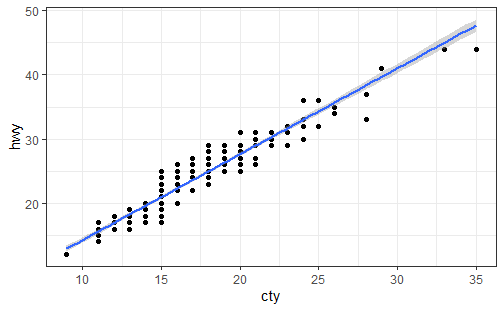

```r
ggplot(mpg, aes(cty, hwy)) +
  geom_point() +
  geom_smooth(method = "lm")
```

2. What does ggplot(mpg, aes(model, manufacturer)) + geom_point() show? Is it useful? How could you modify the data to make it more informative?

Each model only belongs to one manufacturer so not useful. And some points hidden Perhaps count models by manufacturer?

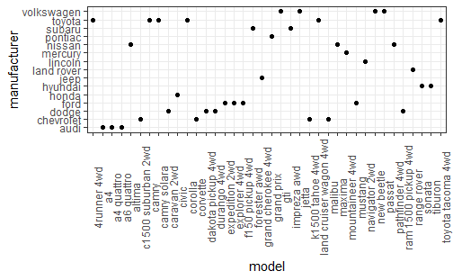

```r
ggplot(mpg, aes(model, manufacturer)) +
    geom_point() +
  # added so I could read text on x-axis
    theme(axis.text.x = element_text(angle = 90))
```

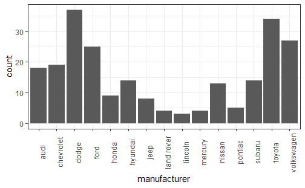

```r
ggplot(mpg, aes(manufacturer)) +
    geom_bar() +
    theme(axis.text.x = element_text(angle = 90))
```

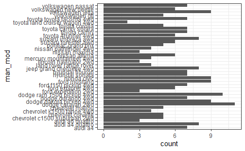

```r
#AP version
df <- mpg %>%
 transmute("man_mod" = paste(manufacturer, model, sep = " "))

ggplot(df, aes(man_mod)) +
 geom_bar() +
 coord_flip()
```

3. Describe the data, aesthetic mappings and layers used for each of the following plots. You’ll need to guess a little because you haven’t seen all the datasets and functions yet, but use your common sense! See if you can predict what the plot will look like before running the code.

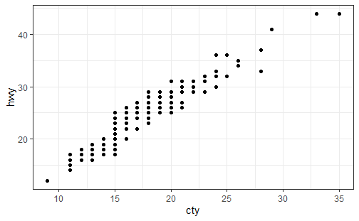

```r
ggplot(mpg, aes(cty, hwy)) +
  geom_point()
```

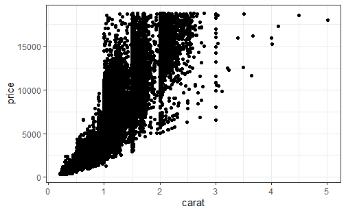

```r
ggplot(diamonds, aes(carat, price)) +
  geom_point()
```

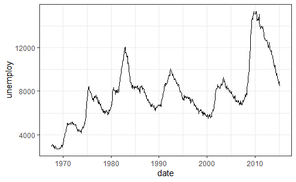

```r
ggplot(economics, aes(date, unemploy)) +
  geom_line()
```

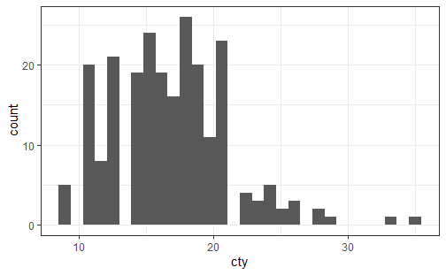

```r
ggplot(mpg, aes(cty)) +
  geom_histogram(bins = 30)
```

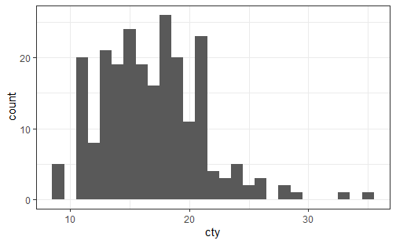

```r
ggplot(mpg, aes(cty)) +
  geom_histogram(binwidth = 1)
```

## 2.4.1 Colour, size, shape and other aesthetic attributes

1. Experiment with the colour, shape and size aesthetics. What happens when you map them to continuous values? What about categorical values? What happens when you use more than one aesthetic in a plot?

Two legends are produced if you use >1 aesthetic in a plot.

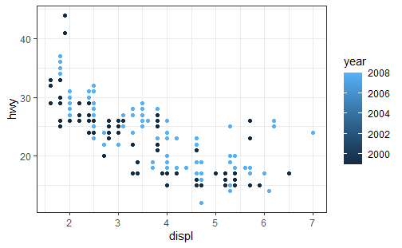

```r
# color continuous
mpg %>%
  ggplot(aes(displ, hwy, color = year)) +
  geom_point()
```

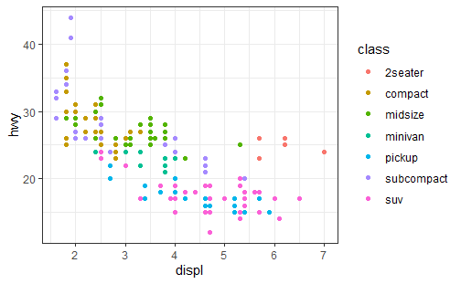

```r
# color categorical
mpg %>%
  ggplot(aes(displ, hwy, color = class)) +
  geom_point()
```

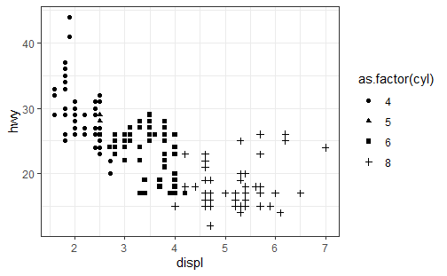

```r
# # shape continuous
# mpg %>%
#   ggplot(aes(displ, hwy, shape = year)) +
#   geom_point()
# # gives following error
# # Error: A continuous variable can not be mapped to shape

# shape categorical
mpg %>%
  ggplot(aes(displ, hwy, shape = as.factor(cyl))) +
  geom_point()
```

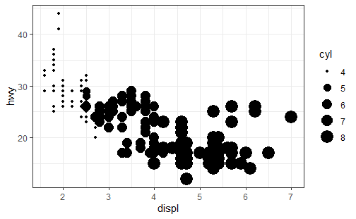

```r
# size continuous
mpg %>%
  ggplot(aes(displ, hwy, size = cyl)) +
  geom_point()
```

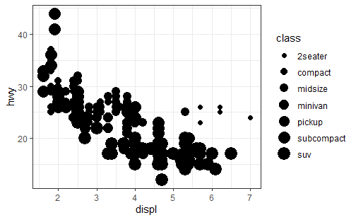

```r
# size categorical
mpg %>%
  ggplot(aes(displ, hwy, size = class)) +
  geom_point()
```

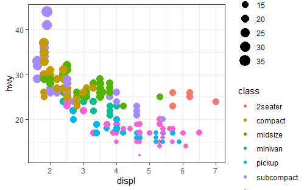

```r
# combine two aethetics
mpg %>%
  ggplot(aes(displ, hwy, color = class, size = cty)) +
  geom_point()
```

2. What happens if you map a continuous variable to shape? Why? What happens if you map trans to shape? Why?

A continuous value cannot be mapped to shape  
Mapping trans to shape gives a warning since it has too many values to be easily visible:  
The shape palette can deal with a maximum of 6 discrete values because more than 6 becomes difficult to discriminate; trans has 10. Consider specifying shapes manually if you must have them.

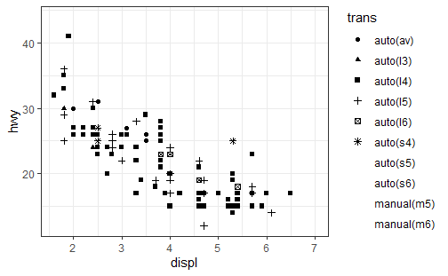

```r
# # shape continuous
# mpg %>%
#    ggplot(aes(displ, hwy, shape = year)) +
#    geom_point()
# # gives following error
# # Error: A continuous variable can not be mapped to shape

# trans to shape
mpg %>%
  ggplot(aes(displ, hwy, shape = trans)) +
  geom_point()
```

```r
NA
NA
```

3. How is drive train related to fuel economy? How is drive train related to engine size and class?

Front wheel drive vehicles generally have better fuel economy than rear or 4 wheel drive.  
Engine size is generally larger for 4 wheel drive vehicles which are generally larger types of vehicles such as trucks or SUV. Engine size is smaller for front wheel drive vehicles which are generally smaller engines. Rear wheel drive have larger engines either 2 seater sports cars, SUVs, and 4 sub compacts which larger engines.

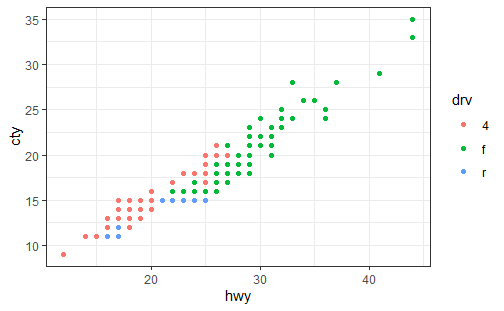

```r
# drive train to fuel economy
mpg %>%
  ggplot(aes(hwy, cty, color = drv)) +
  geom_point()
```

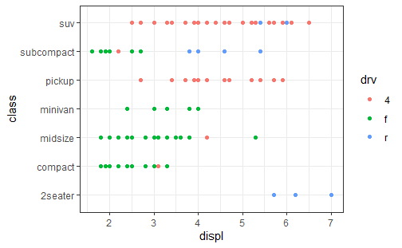

```r
# drive train to engine size and class
mpg %>%
  ggplot(aes(displ, class, color = drv)) +
  geom_point()
```

## 2.5.1 Facetting

1. What happens if you try to facet by a continuous variable like hwy? What about cyl? What’s the key difference?

Facetting is most useful with categorical variable. A continuous variable, such as hwy, has too many graphs with too few points. Using cyl gives a more informative set of graphs.

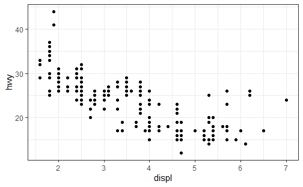

```r
# without facetting
mpg %>%
  ggplot(aes(displ, hwy)) +
  geom_point()
```

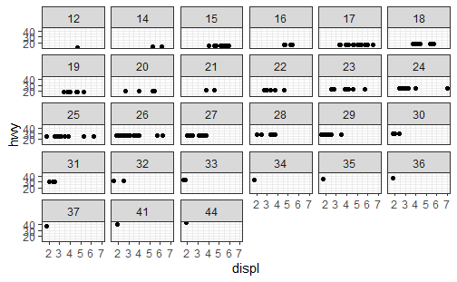

```r
# try facetting by a continuous variable
mpg %>%
  ggplot(aes(displ, hwy)) +
  geom_point() +
  facet_wrap(~hwy)
```

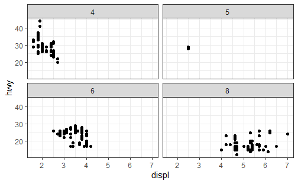

```r
# try facetting by a continuous variable
mpg %>%
  ggplot(aes(displ, hwy)) +
  geom_point() +
  facet_wrap(~cyl)
```

2. Use facetting to explore the 3-way relationship between fuel economy, engine size, and number of cylinders. How does facetting by number of cylinders change your assessement of the relationship between engine size and fuel economy?

As engines get bigger the fuel efficiency drops within each number of cylinders. The number of cylinders and engine displacement are related and go up together.

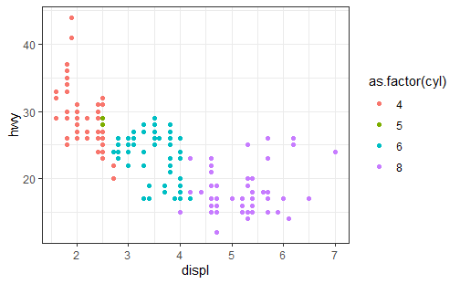

```r
# without facetting
mpg %>%
  ggplot(aes(displ, hwy, colour = as.factor(cyl))) +
  geom_point()
```

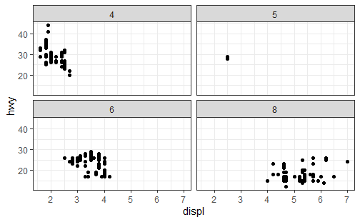

```r
# with facetting
mpg %>%
  ggplot(aes(displ, hwy)) +
  geom_point() +
  facet_wrap(~cyl)
```

3. Read the documentation for facet_wrap(). What arguments can you use to control how many rows and columns appear in the output?

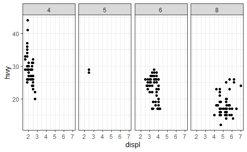

```r
?facet_wrap

# example graph with number of columns controlled
mpg %>%
  ggplot(aes(displ, hwy)) +
  geom_point() +
  facet_wrap(~cyl, nrow = 1)
```

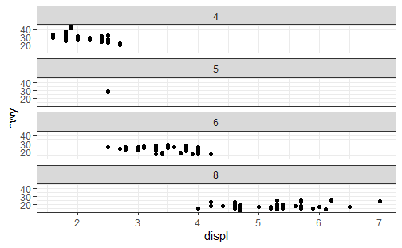

```r
# example graph with number of rows controlled
mpg %>%
  ggplot(aes(displ, hwy)) +
  geom_point() +
  facet_wrap(~cyl, ncol = 1)
```

4. What does the scales argument to facet_wrap() do? When might you use it?

The scales arguement allows the axis (either x, y or both) to be different between graphs. The default is to fix all scales to the same range. This makes is harder to compare graphs, but may be necessary if the scales are very different between graphs so see the nuances.

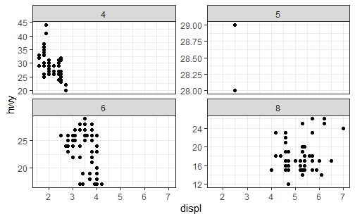

```r
# example with scales argument
mpg %>%
  ggplot(aes(displ, hwy)) +
  geom_point() +
  facet_wrap(~cyl, scales = "free_y")
```

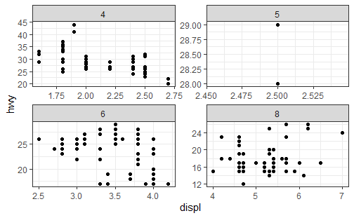

```r
# example CK
mpg %>%
  ggplot(aes(displ, hwy)) +
  geom_point() +
  facet_wrap(~cyl, scales = "free")
```